# Part iiA: Regression models

INFSCI 2595 Final

Ben Stein

4/27/2022

# About this document

In this document, I fit nine regression models and evaluate them against the training data. In Part iiD, I choose the best of these models for additional tuning and validation against a test set.

# Setup (libraries and tools)

## Libraries and tools

```r
library(tidyverse)
source("./tools.R")
set.seed(2022)
```

## Load preprocessed data

Since this document is concerned with regression models, I select only the variables of interest. Since we’re not using `caret` to tune or multisample, I center and scale here, too.

```r
df <- load_project_data(center_and_scale = TRUE) %>%
  select(-outcome_numeric)

df %>% glimpse
```

```
## Rows: 677
## Columns: 36
## $ region       <fct> XX, XX, XX, XX, XX, XX, XX, XX, XX, XX, XX, XX, XX, XX, X~
## $ customer     <fct> B, B, B, B, B, B, B, B, B, B, B, B, B, B, B, B, B, B, B, ~
## $ xb_01        <dbl> 0.30863578, -1.17801052, -0.68246175, -0.42477639, -0.410~
## $ xb_02        <dbl> -0.52769021, -1.43287502, -1.13114675, 1.58440769, 0.0757~
## $ xb_03        <dbl> 0.92465680, -0.07214679, 0.26012107, -2.39802182, -0.7366~
## $ xn_01        <dbl> 0.82042446, 0.25145112, 0.25145112, -0.01406977, -0.40929~
## $ xn_02        <dbl> -0.2245211, -0.5623007, 0.1132584, 1.8021561, -0.2245211,~
## $ xn_03        <dbl> 1.2762480, 0.9010765, 0.1507336, -0.9747808, -1.3499523, ~
## $ xa_01        <dbl> 1.00106429, -1.29333076, 0.23626594, -0.25320501, -0.4134~
## $ xa_02        <dbl> -0.1773302, -1.4605523, -0.6050709, 2.2465338, 0.5355710,~
## $ xa_03        <dbl> 1.4593153, -0.1494432, 0.9230625, -1.9369527, -1.0431979,~
## $ xb_04        <dbl> 0.26039081, -0.22110912, -0.22110912, -0.37271282, 0.1035~
## $ xb_05        <dbl> 0.86178234, 0.55137413, 0.55137413, -2.24229976, -0.84546~
```

[output cut: 23 more lines]

# Models

## Model 1: categorical features only (linear additive)

```r
lm_model1 <- lm(
  response_log ~ region + customer,
  data = df
)
```

## Model 2: Continuous features only (linear additive)

```r
lm_model2 <- lm(
  response_log ~ .,
  data = df %>% select(where(is.numeric))
)
```

## Model 3: All features (linear additive)

```r
lm_model3 <- lm(
  response_log ~ .,
  data = df
)
```

## Model 4: Interact region with continuous inputs

```r
lm_model4 <- lm(
  response_log ~ region * (.),
  data = df %>% select(where(is.numeric), region)
)
```

## Model 5: Interact customer with continuous inputs

```r
lm_model5 <- lm(
  response_log ~ customer * (.),
  data = df %>% select(where(is.numeric), customer)
)
```

## Model 6: All pairwise interactions of continuous inputs

```r
lm_model6 <- lm(
  response_log ~ (.)^2,
  data = df %>%
    select(where(is.numeric))
)
```

## Model 7: P-value all-stars (squared)

I’m throwing wild haymakers here (my signature move in this project), but for my first solo model, I decided to take the the predictors which were significant in the model with every variable included (Model 3, above) and apply a new basis function to continuous variable. I chose the parabolic as the new basis.

```r
lm_model3_coef <- summary(lm_model3)$coefficients

lm_model7_significant_predictors <- lm_model3_coef %>%
  as_tibble %>%
  mutate(predictor = row.names(lm_model3_coef)) %>%
  rename(p = 4) %>%
  filter(p < .05)

lm_model7_significant_predictors
```

```
## # A tibble: 14 x 5
##    Estimate `Std. Error` `t value`        p predictor
##       <dbl>        <dbl>     <dbl>    <dbl> <chr>
##  1    0.518       0.0689      7.53 1.75e-13 regionYY
##  2   -0.418       0.0903     -4.63 4.38e- 6 regionZZ
##  3   -0.203       0.101      -2.00 4.54e- 2 customerG
##  4    0.422       0.130       3.25 1.20e- 3 customerK
##  5   -0.367       0.108      -3.40 7.20e- 4 customerM
##  6   -0.431       0.161      -2.68 7.53e- 3 customerQ
##  7    0.192       0.0925      2.07 3.84e- 2 xa_02
##  8   -0.449       0.146      -3.08 2.18e- 3 xb_04
##  9    0.255       0.0703      3.62 3.14e- 4 xb_07
## 10    0.199       0.0817      2.44 1.49e- 2 xb_08
## 11    0.286       0.136       2.10 3.59e- 2 xn_04
## 12    0.178       0.0878      2.03 4.25e- 2 xn_05
## 13   -0.180       0.0730     -2.46 1.41e- 2 xn_08
## 14    0.508       0.111       4.57 5.78e- 6 xw_01
```

Okay, we’ve got our predictors. Let’s model using the parabolic basis function.

```r
lm_model7 <- lm(
  formula = response_log ~ region +
    customer +
    I(xa_02^2) +
    I(xb_04^2) +
    I(xb_07^2) +
    I(xb_08^2) +
    I(xn_04^2) +
    I(xn_05^2) +
    I(xn_08^2) +
    I(xw_01^2),
  data = df
)
```

## Model 8:

For this model, I chose predictors based on my EDA. I’m specifically interested in predictors which:

- Are sentiment-based and continuous
- Have an apparently Gaussian distribution
- Have a high number of unique values
- Are not highly correlated with other variables in the same group

We need a new basis function to meet requirements. I’m going to try splines, because I thought some of the loess lines looked spliney. I chose a 20-degrees-of-freedom basis pretty much at random. Okay, let’s model.

```r
lm_model8 <- lm(
  formula = response_log ~ splines::ns(xa_07, df = 20) +
    splines::ns(xa_08, df = 20) +
    splines::ns(xb_08, df = 20) +
    splines::ns(xb_08, df = 20) +
    splines::ns(xn_08, df = 20) +
    splines::ns(xn_08, df = 20) +
    splines::ns(xs_01, df = 20) +
    splines::ns(xs_02, df = 20) +
    splines::ns(xs_03, df = 20) +
    splines::ns(xs_04, df = 20),
  data = df
)
```

## Model 9: `findCorrelation` based selection

Here, I use `findCorrelation` from `caret` to choose numeric predictors which have highest pairwise correlation. Note that this approach is different from model 8 because I don’t consider apparent distribution or number of unique values. I also exclude categorical variables from this model.

```r
lm_model9_correlated_predictors <- df %>%
  select(-region, -customer, -response_log) %>%
  cor %>%
  caret::findCorrelation(cutoff = .8, names = TRUE)

lm_model9_correlated_predictors
```

```
##  [1] "xb_05" "xa_05" "xb_03" "xn_05" "xb_06" "xb_04" "xa_02" "xb_01" "xa_04"
## [10] "xn_04"
```

```r
lm_model9 <- lm(
  formula = response_log ~
    splines::ns(xa_02, df = 3) +
    splines::ns(xa_04, df = 3) +
    splines::ns(xa_05, df = 3) +
    splines::ns(xb_01, df = 3) +
    splines::ns(xb_03, df = 3) +
    splines::ns(xb_04, df = 3) +
    splines::ns(xb_05, df = 3) +
    splines::ns(xb_06, df = 3) +
    splines::ns(xn_04, df = 3) +
    splines::ns(xn_05, df = 3),
  data = df
)
```

# Comparison

Let’s use `broom` to examine some summary statistics. I couldn’t find an easy RMSE with pure `lm`, so I had to roll my own, which I hopefully did correctly.

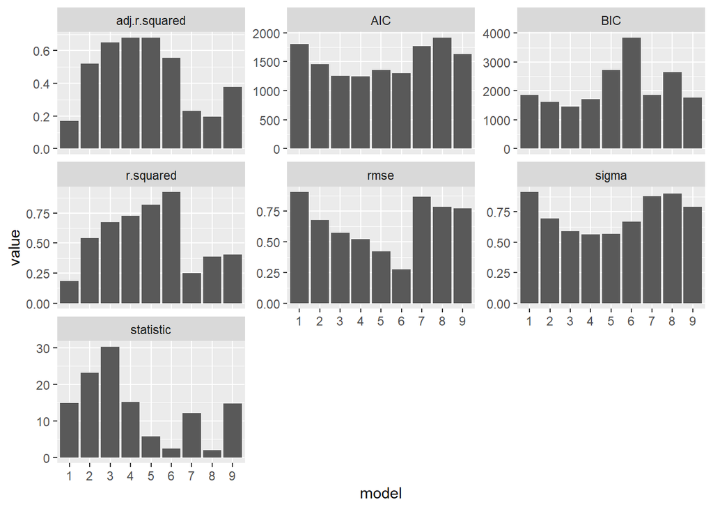

```r
lm_all_models <- list(
  lm_model1,
  lm_model2,
  lm_model3,
  lm_model4,
  lm_model5,
  lm_model6,
  lm_model7,
  lm_model8,
  lm_model9
)

get_rmse <- function(model) {
  pred <- predict(model, newdata = df)
  obs <- df$response_log

  sum((pred-obs)^2) %>%
    sum %>%
    magrittr::divide_by(length(obs)) %>%
    sqrt()
}

df_lm_all_models <- lm_all_models %>%
  purrr::map_df(broom::glance) %>%
  select(
    r.squared,
    adj.r.squared,
    sigma,
    AIC,
    BIC,
    statistic
  ) %>%
  mutate(
    model = paste(1:9, sep=""),
    rmse = lm_all_models %>% purrr::map_dbl(get_rmse)
  )
df_lm_all_models %>%
  pivot_longer(cols = -model) %>%
  ggplot(mapping = aes(x = model, y = value)) +
  geom_col() +
  facet_wrap(~ name, scales = "free_y")
```

## R^2 and adjusted R^2

Let’s look at these two by themselves so we can see them on the same scale:

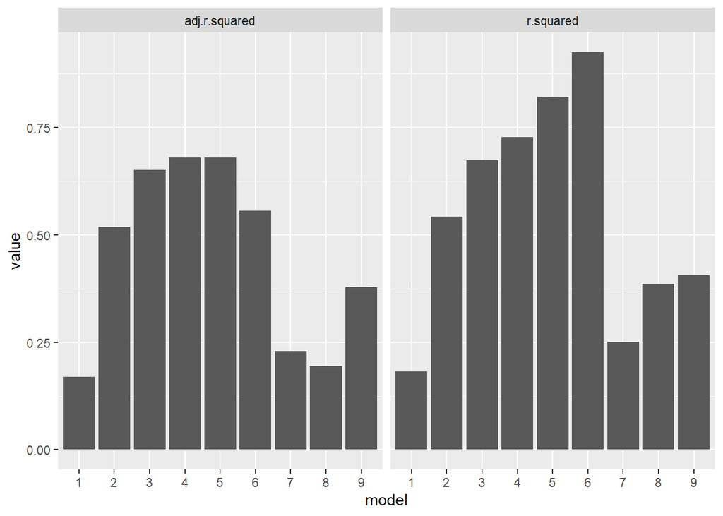

```r
df_lm_all_models %>%
  select(model, r.squared, adj.r.squared) %>%
  pivot_longer(cols = -model) %>%
  ggplot(mapping = aes(x = model, y = value)) +
  geom_col() +
  facet_wrap(~ name)
```

Let’s supplement this analysis with examination of the information criteria.

## AIC/BIC

To be transparent, I checked both AIC and BIC because of [this StackExchange thread](https://stats.stackexchange.com/questions/577/is-there-any-reason-to-prefer-the-aic-or-bic-over-the-other).

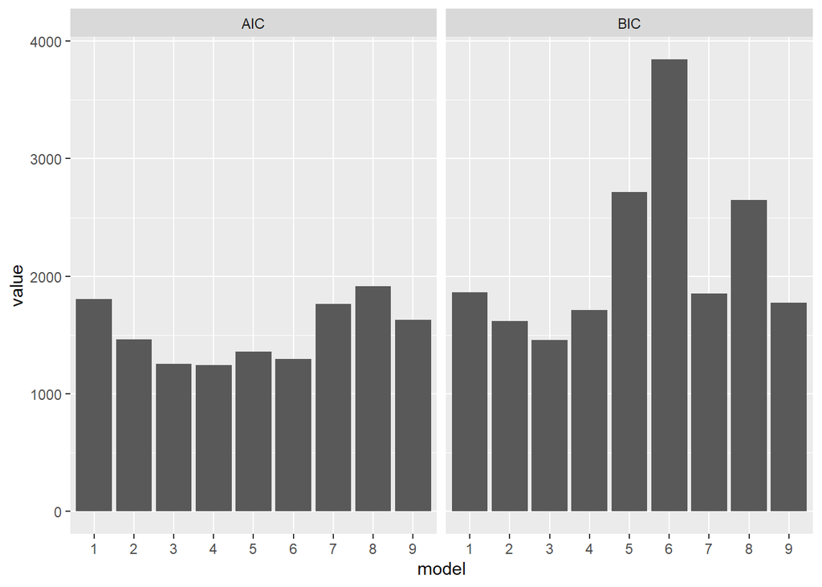

```r
df_lm_all_models %>%
  select(model, AIC, BIC) %>%
  pivot_longer(cols = -model) %>%
  ggplot(mapping = aes(x = model, y = value)) +
  geom_col() +
  facet_wrap(~ name)
```

Examining AIC doesn’t change my mind much, since the models with strongest AIC are also the ones that have the best $r^2$ / adj $r^2$. Model 3 makes a strong showing here, but it’s clearly worse than Model 5 by $r^2$.

## RMSE

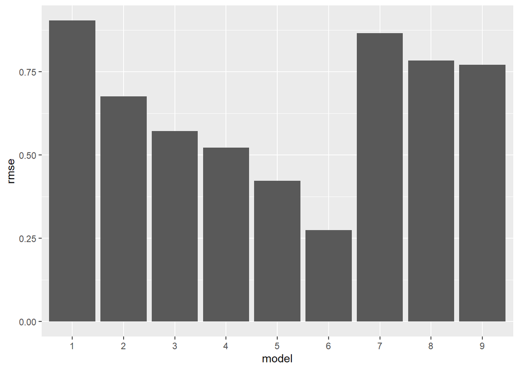

```r
df_lm_all_models %>%
  select(model, rmse) %>%
  ggplot(mapping = aes(x = model, y = rmse)) +
  geom_col()
```

Model 6 sings its siren song again, but we’re not fooled. Probably. I dunno, Model 6 might be great, but I’m suspicious because of its BIC, low adjusted $r^2$, and high number of predictors. Maybe we’ll call it a backup.

Meanwhile, model 5 continues to look good by this metric, with 3 and 4 not far behind.

# Moving forward

Based on this analysis, I retain models 5, 4, and 6 for future analysis.

```r
readr::write_rds(lm_model5, "./models/lm_rank1_model5.rds")
readr::write_rds(lm_model4, "./models/lm_rank2_model4.rds")
readr::write_rds(lm_model6, "./models/lm_rank3_model6.rds")
```